# Assignment 10: Data Scraping

Wynona Curaming

## OVERVIEW

This exercise accompanies the lessons in Environmental Data Analytics on data scraping.

## Directions

1. Rename this file `<FirstLast>_A10_DataScraping.Rmd` (replacing `<FirstLast>` with your first and last name).
2. Change “Student Name” on line 3 (above) with your name.
3. Work through the steps, **creating code and output** that fulfill each instruction.
4. Be sure your code is tidy; use line breaks to ensure your code fits in the knitted output.
5. Be sure to **answer the questions** in this assignment document.
6. When you have completed the assignment, **Knit** the text and code into a single PDF file.

## Set up

1. Set up your session:
- Load the packages `tidyverse`, `rvest`, and any others you end up using.
- Check your working directory

```r
#1
library(tidyverse);library(lubridate);library(viridis);library(here);library(rvest)
library(dataRetrieval);library(tidycensus);library(ggplot2);library(dplyr)

getwd()
```

```
## [1] "/home/guest/ENV 872/EDA_Spring2024"
```

2. We will be scraping data from the NC DEQs Local Water Supply Planning website, specifically the Durham’s 2022 Municipal Local Water Supply Plan (LWSP):
- Navigate to https://www.ncwater.org/WUDC/app/LWSP/search.php
- Scroll down and select the LWSP link next to Durham Municipality.
- Note the web address: https://www.ncwater.org/WUDC/app/LWSP/report.php?pwsid=03-32-010&year=2022

Indicate this website as the as the URL to be scraped. (In other words, read the contents into an `rvest` webpage object.)

```r
#2
Water_URL<- read_html('https://www.ncwater.org/WUDC/app/LWSP/report.php?pwsid=03-32-010&year=2022')
Water_URL
```

```
## {html_document}
## <html xmlns="http://www.w3.org/1999/xhtml" lang="en" xml:lang="en">
## [1] <head>\n<title>DWR :: Local Water Supply Planning</title>\n<meta http-equ ...
## [2] <body id="plan">\r\n<!--<div id="division-header">\r\n<a name="top" href= ...
```

3. The data we want to collect are listed below:
- From the “1. System Information” section:
- Water system name
- PWSID
- Ownership
- From the “3. Water Supply Sources” section:
- Maximum Day Use (MGD) - for each month

In the code chunk below scrape these values, assigning them to four separate variables.

> HINT: The first value should be “Durham”, the second “03-32-010”, the third “Municipality”, and the last should be a vector of 12 numeric values (represented as strings)“. #I’m confused about the class for this. Should it be numeric or vector or strings? Right now it is character, even though I try as.numeric or toString()

```r
#3
water_system_name<-Water_URL%>%
  html_nodes("div+ table tr:nth-child(1) td:nth-child(2)")%>%
  html_text()
water_system_name
```

```
## [1] "Durham"
```

```r
PWSID<-Water_URL%>%
  html_nodes("td tr:nth-child(1) td:nth-child(5)")%>%
  html_text()
PWSID
```

```
## [1] "03-32-010"
```

```r
ownership<-Water_URL%>%
  html_nodes("div+ table tr:nth-child(2) td:nth-child(4)")%>%
  html_text()
ownership
```

```
## [1] "Municipality"
```

```r
max_day_use_monthly<-Water_URL%>%
  html_nodes("th~ td+ td")%>%
  html_text()
max_day_use_monthly
```

```
##  [1] "36.1000" "43.4200" "52.4900" "30.5000" "42.5900" "34.8800" "39.9100"
##  [8] "43.3200" "32.5300" "34.6600" "41.8000" "37.5300"
```

```r
as.numeric(max_day_use_monthly)
```

```
##  [1] 36.10 43.42 52.49 30.50 42.59 34.88 39.91 43.32 32.53 34.66 41.80 37.53
```

```r
class(max_day_use_monthly)
```

```
## [1] "character"
```

4. Convert your scraped data into a dataframe. This dataframe should have a column for each of the 4 variables scraped and a row for the month corresponding to the withdrawal data. Also add a Date column that includes your month and year in data format. (Feel free to add a Year column too, if you wish.)

> TIP: Use `rep()` to repeat a value when creating a dataframe.

> NOTE: It’s likely you won’t be able to scrape the monthly widthrawal data in chronological order. You can overcome this by creating a month column manually assigning values in the order the data are scraped: “Jan”, “May”, “Sept”, “Feb”, etc… Or, you could scrape month values from the web page…
5. Create a line plot of the maximum daily withdrawals across the months for 2022

```r
#4
#making a df
water_df<-data.frame(water_system_name,
            PWSID,
            ownership,
            "Max_day_use_monthly"=as.numeric(max_day_use_monthly))

#adding month & date columns
month<- c(1,5,9,2,6,10,3,7,11,4,8,12)
year<-c(2022)

water_df['Month']=month
water_df
```

| water_system_name | PWSID | ownership | Max_day_use_monthly | Month |
| --- | --- | --- | --- | --- |
| Durham | 03-32-010 | Municipality | 36.10 | 1 |
| Durham | 03-32-010 | Municipality | 43.42 | 5 |
| Durham | 03-32-010 | Municipality | 52.49 | 9 |
| Durham | 03-32-010 | Municipality | 30.50 | 2 |
| Durham | 03-32-010 | Municipality | 42.59 | 6 |
| Durham | 03-32-010 | Municipality | 34.88 | 10 |
| Durham | 03-32-010 | Municipality | 39.91 | 3 |
| Durham | 03-32-010 | Municipality | 43.32 | 7 |
| Durham | 03-32-010 | Municipality | 32.53 | 11 |
| Durham | 03-32-010 | Municipality | 34.66 | 4 |

[output cut: 2 more lines]

```r
water_df['Date']= my(paste(month, year))

water_df
```

| water_system_name | PWSID | ownership | Max_day_use_monthly | Month | Date |
| --- | --- | --- | --- | --- | --- |
| Durham | 03-32-010 | Municipality | 36.10 | 1 | 2022-01-01 |
| Durham | 03-32-010 | Municipality | 43.42 | 5 | 2022-05-01 |
| Durham | 03-32-010 | Municipality | 52.49 | 9 | 2022-09-01 |
| Durham | 03-32-010 | Municipality | 30.50 | 2 | 2022-02-01 |
| Durham | 03-32-010 | Municipality | 42.59 | 6 | 2022-06-01 |
| Durham | 03-32-010 | Municipality | 34.88 | 10 | 2022-10-01 |
| Durham | 03-32-010 | Municipality | 39.91 | 3 | 2022-03-01 |
| Durham | 03-32-010 | Municipality | 43.32 | 7 | 2022-07-01 |
| Durham | 03-32-010 | Municipality | 32.53 | 11 | 2022-11-01 |
| Durham | 03-32-010 | Municipality | 34.66 | 4 | 2022-04-01 |

[output cut: 2 more lines]

```r
#reordering for chronological order
water_chronological_df<- water_df[order(water_df$Month),]
water_chronological_df
```

|  | water_system_name | PWSID | ownership | Max_day_use_monthly | Month | Date |
| --- | --- | --- | --- | --- | --- | --- |
| 1 | Durham | 03-32-010 | Municipality | 36.10 | 1 | 2022-01-01 |
| 4 | Durham | 03-32-010 | Municipality | 30.50 | 2 | 2022-02-01 |
| 7 | Durham | 03-32-010 | Municipality | 39.91 | 3 | 2022-03-01 |
| 10 | Durham | 03-32-010 | Municipality | 34.66 | 4 | 2022-04-01 |
| 2 | Durham | 03-32-010 | Municipality | 43.42 | 5 | 2022-05-01 |
| 5 | Durham | 03-32-010 | Municipality | 42.59 | 6 | 2022-06-01 |
| 8 | Durham | 03-32-010 | Municipality | 43.32 | 7 | 2022-07-01 |
| 11 | Durham | 03-32-010 | Municipality | 41.80 | 8 | 2022-08-01 |
| 3 | Durham | 03-32-010 | Municipality | 52.49 | 9 | 2022-09-01 |
| 6 | Durham | 03-32-010 | Municipality | 34.88 | 10 | 2022-10-01 |

[output cut: 2 more lines]

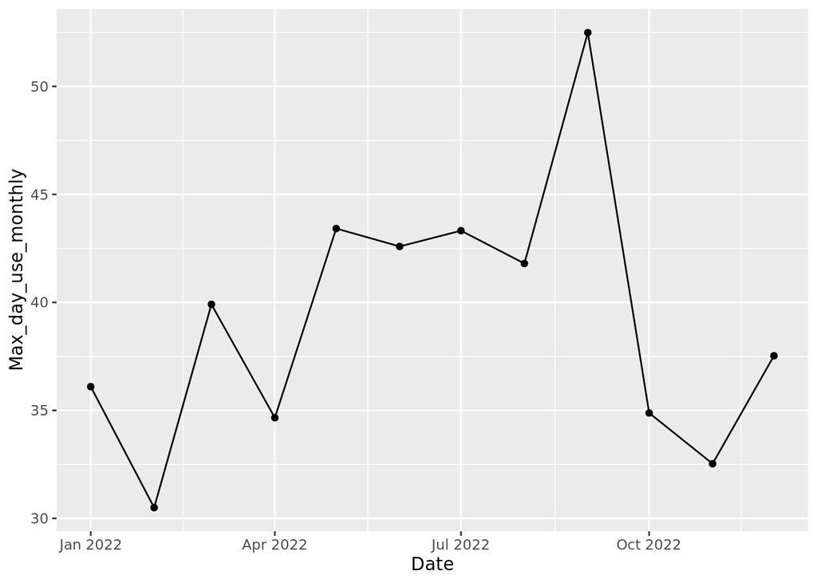

```r
#5
ggplot(aes(x=Date, y= Max_day_use_monthly), data=water_chronological_df)+geom_point()+geom_line()
```

6. Note that the PWSID and the year appear in the web address for the page we scraped. Construct a function using your code above that can scrape data for any PWSID and year for which the NC DEQ has data. **Be sure to modify the code to reflect the year and site (pwsid) scraped**.

```r
#6.

scrape.it<-function(the_year, the_facility){
  base_URL<-'https://www.ncwater.org/WUDC/app/LWSP/report.php?'
  the_scrape_url <- paste0(base_URL,'pwsid=',the_facility,'&year=', the_year)
  print(the_scrape_url)
  the_facility<-'03-32-010'
  the_website <- read_html(the_scrape_url)

  the_month<- c(1,5,9,2,6,10,3,7,11,4,8,12)

  water_system_name_anyyear<-the_website%>%
    html_nodes("div+ table tr:nth-child(1) td:nth-child(2)")%>%
    html_text()
  water_system_name

  PWSID_anyyear<-the_website%>%
    html_nodes("td tr:nth-child(1) td:nth-child(5)")%>%
    html_text()
  PWSID

  ownership_anyyear<-the_website%>%
    html_nodes("div+ table tr:nth-child(2) td:nth-child(4)")%>%
    html_text()
  ownership

  max_day_use_monthly_anyyear<-the_website%>%
    html_nodes("th~ td+ td")%>%
    html_text()

  df_water<- data.frame("Month" = the_month,
                               "Year" = the_year,
                               "Max_Day_Use" = as.numeric(max_day_use_monthly_anyyear)) %>%
    mutate(Water_System_Name = !!water_system_name_anyyear,
           PWSID = !!PWSID_anyyear,
           Ownership = !!ownership_anyyear,
           Date = my(paste(Month,"-",Year)))
  return(df_water)
}
```

7. Use the function above to extract and plot max daily withdrawals for Durham (PWSID=‘03-32-010’) for each month in 2015

```r
#7
max_daily_withdrawals_Durham_2015_df <- scrape.it(2015,'03-32-010')
```

```
## [1] "https://www.ncwater.org/WUDC/app/LWSP/report.php?pwsid=03-32-010&year=2015"
```

```r
view(max_daily_withdrawals_Durham_2015_df)
```

8. Use the function above to extract data for Asheville (PWSID = 01-11-010) in 2015. Combine this data with the Durham data collected above and create a plot that compares Asheville’s to Durham’s water withdrawals.

```r
#8
max_daily_withdrawals_Asheville_2015_df <- scrape.it(2015,'01-11-010')
```

```
## [1] "https://www.ncwater.org/WUDC/app/LWSP/report.php?pwsid=01-11-010&year=2015"
```

```r
view(max_daily_withdrawals_Asheville_2015_df)

max_daily_withdrawals_Asheville_Durham_2015_df<-
  bind_rows(max_daily_withdrawals_Asheville_2015_df,
            max_daily_withdrawals_Durham_2015_df)

max_daily_withdrawals_Asheville_Durham_2015_df
```

| Month | Year | Max_Day_Use | Water_System_Name | PWSID | Ownership | Date |
| --- | --- | --- | --- | --- | --- | --- |
| 1 | 2015 | 20.81 | Asheville | 01-11-010 | Municipality | 2015-01-01 |
| 5 | 2015 | 23.95 | Asheville | 01-11-010 | Municipality | 2015-05-01 |
| 9 | 2015 | 22.97 | Asheville | 01-11-010 | Municipality | 2015-09-01 |
| 2 | 2015 | 24.54 | Asheville | 01-11-010 | Municipality | 2015-02-01 |
| 6 | 2015 | 23.53 | Asheville | 01-11-010 | Municipality | 2015-06-01 |
| 10 | 2015 | 21.32 | Asheville | 01-11-010 | Municipality | 2015-10-01 |
| 3 | 2015 | 21.42 | Asheville | 01-11-010 | Municipality | 2015-03-01 |
| 7 | 2015 | 23.68 | Asheville | 01-11-010 | Municipality | 2015-07-01 |
| 11 | 2015 | 20.45 | Asheville | 01-11-010 | Municipality | 2015-11-01 |
| 4 | 2015 | 21.60 | Asheville | 01-11-010 | Municipality | 2015-04-01 |

[output cut: 14 more lines]

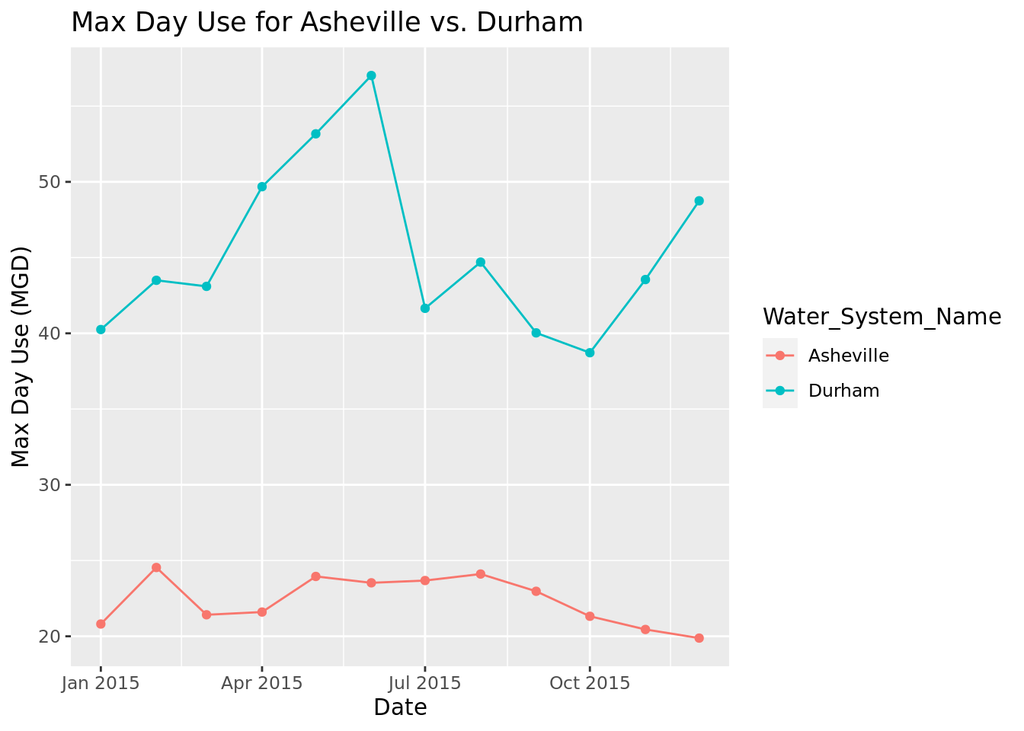

```r
ggplot(max_daily_withdrawals_Asheville_Durham_2015_df, aes(x=Date,
                                                           y=Max_Day_Use, color=Water_System_Name))+
  geom_point()+geom_line()+
  labs(title="Max Day Use for Asheville vs. Durham", y="Max Day Use (MGD)")
```

9. Use the code & function you created above to plot Asheville’s max daily withdrawal by months for the years 2010 thru 2021.Add a smoothed line to the plot (method = ‘loess’).

> TIP: See Section 3.2 in the “10_Data_Scraping.Rmd” where we apply “map2()” to iteratively run a function over two inputs. Pipe the output of the map2() function to `bindrows()` to combine the dataframes into a single one.

```r
#9
#Mapping out the data from 2010-2021 for Asheville (Quicker way)
water_df_2010_to_2021_v2<-map2(seq(2010,2021), '01-11-010', scrape.it)
```

```
## [1] "https://www.ncwater.org/WUDC/app/LWSP/report.php?pwsid=01-11-010&year=2010"
## [1] "https://www.ncwater.org/WUDC/app/LWSP/report.php?pwsid=01-11-010&year=2011"
## [1] "https://www.ncwater.org/WUDC/app/LWSP/report.php?pwsid=01-11-010&year=2012"
## [1] "https://www.ncwater.org/WUDC/app/LWSP/report.php?pwsid=01-11-010&year=2013"
## [1] "https://www.ncwater.org/WUDC/app/LWSP/report.php?pwsid=01-11-010&year=2014"
## [1] "https://www.ncwater.org/WUDC/app/LWSP/report.php?pwsid=01-11-010&year=2015"
## [1] "https://www.ncwater.org/WUDC/app/LWSP/report.php?pwsid=01-11-010&year=2016"
## [1] "https://www.ncwater.org/WUDC/app/LWSP/report.php?pwsid=01-11-010&year=2017"
## [1] "https://www.ncwater.org/WUDC/app/LWSP/report.php?pwsid=01-11-010&year=2018"
## [1] "https://www.ncwater.org/WUDC/app/LWSP/report.php?pwsid=01-11-010&year=2019"
## [1] "https://www.ncwater.org/WUDC/app/LWSP/report.php?pwsid=01-11-010&year=2020"
## [1] "https://www.ncwater.org/WUDC/app/LWSP/report.php?pwsid=01-11-010&year=2021"
```

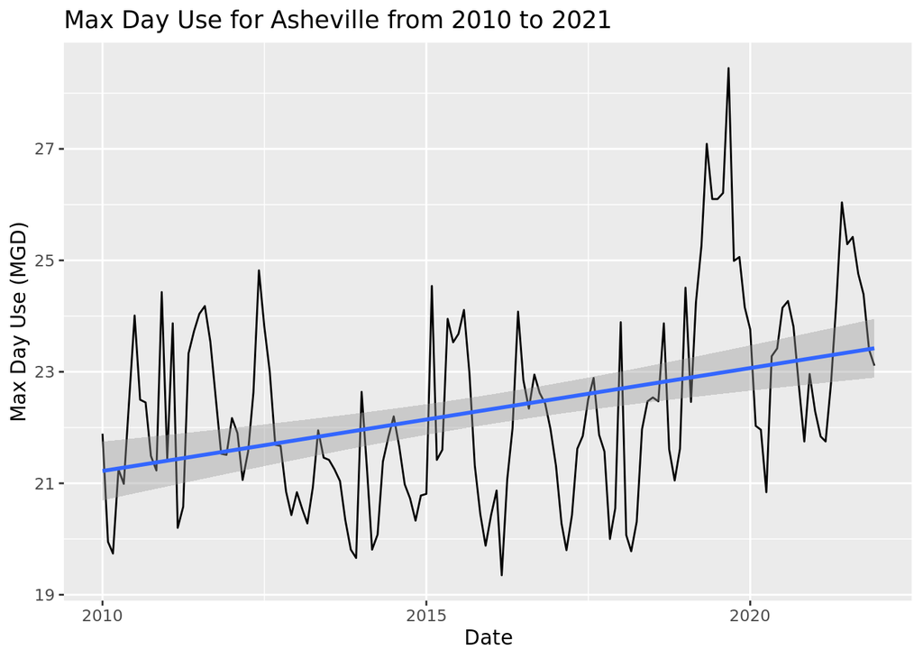

```r
water_df_2010_to_2021_v2<-bind_rows(water_df_2010_to_2021_v2)

ggplot(water_df_2010_to_2021_v2,aes(y = Max_Day_Use, x=Date)) +
  geom_line()+geom_smooth(method="lm")+labs(title="Max Day Use for Asheville from 2010 to 2021", y="Max Day Use (MGD)")
```

```r
#Manual way of mapping the data (feel free to ignore)
Asheville_2010 <- scrape.it(2010,'01-11-010')
```

```
## [1] "https://www.ncwater.org/WUDC/app/LWSP/report.php?pwsid=01-11-010&year=2010"
```

```r
Asheville_2011 <- scrape.it(2011,'01-11-010')
```

```
## [1] "https://www.ncwater.org/WUDC/app/LWSP/report.php?pwsid=01-11-010&year=2011"
```

```r
Asheville_2012 <- scrape.it(2012,'01-11-010')
```

```
## [1] "https://www.ncwater.org/WUDC/app/LWSP/report.php?pwsid=01-11-010&year=2012"
```

```r
Asheville_2013 <- scrape.it(2013,'01-11-010')
```

```
## [1] "https://www.ncwater.org/WUDC/app/LWSP/report.php?pwsid=01-11-010&year=2013"
```

```r
Asheville_2014 <- scrape.it(2014,'01-11-010')
```

```
## [1] "https://www.ncwater.org/WUDC/app/LWSP/report.php?pwsid=01-11-010&year=2014"
```

```r
Asheville_2015 <- scrape.it(2015,'01-11-010')
```

```
## [1] "https://www.ncwater.org/WUDC/app/LWSP/report.php?pwsid=01-11-010&year=2015"
```

```r
Asheville_2016 <- scrape.it(2016,'01-11-010')
```

```
## [1] "https://www.ncwater.org/WUDC/app/LWSP/report.php?pwsid=01-11-010&year=2016"
```

```r
Asheville_2017 <- scrape.it(2017,'01-11-010')
```

```
## [1] "https://www.ncwater.org/WUDC/app/LWSP/report.php?pwsid=01-11-010&year=2017"
```

```r
Asheville_2018 <- scrape.it(2018,'01-11-010')
```

```
## [1] "https://www.ncwater.org/WUDC/app/LWSP/report.php?pwsid=01-11-010&year=2018"
```

```r
Asheville_2019 <- scrape.it(2019,'01-11-010')
```

```
## [1] "https://www.ncwater.org/WUDC/app/LWSP/report.php?pwsid=01-11-010&year=2019"
```

```r
Asheville_2020 <- scrape.it(2020,'01-11-010')
```

```
## [1] "https://www.ncwater.org/WUDC/app/LWSP/report.php?pwsid=01-11-010&year=2020"
```

```r
Asheville_2021 <- scrape.it(2021,'01-11-010')
```

```
## [1] "https://www.ncwater.org/WUDC/app/LWSP/report.php?pwsid=01-11-010&year=2021"
```

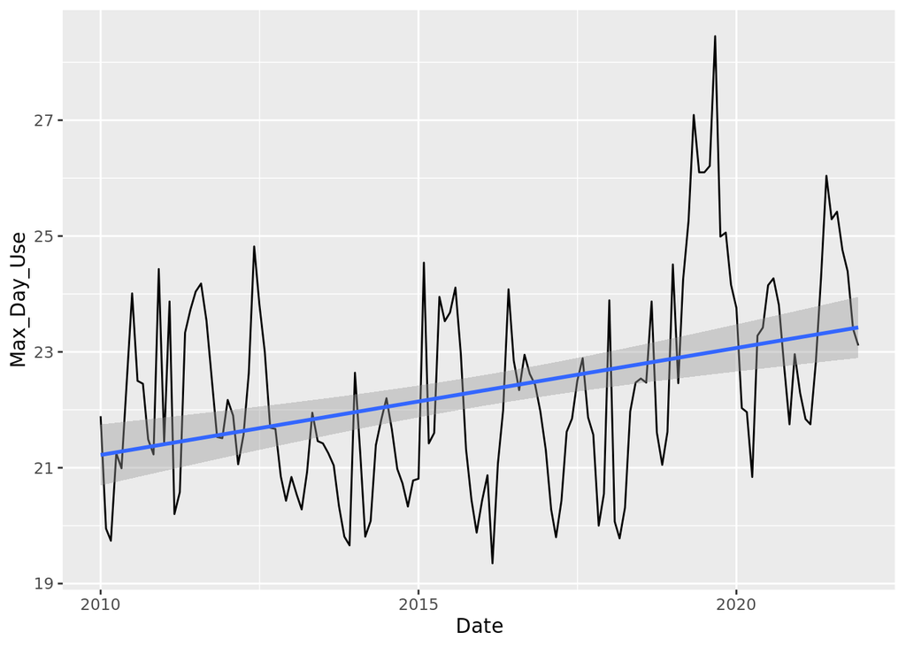

```r
water_df_2010_to_2011_manual<-bind_rows(Asheville_2010, Asheville_2011,Asheville_2012, Asheville_2013,
                                        Asheville_2014, Asheville_2015, Asheville_2016, Asheville_2017, Asheville_2018,
                                        Asheville_2019, Asheville_2020, Asheville_2021)

#Plot
ggplot(water_df_2010_to_2011_manual,
       aes(y = Max_Day_Use, x=Date)) +
  geom_line()+geom_smooth(method="lm")
```

Question: Just by looking at the plot (i.e. not running statistics), does Asheville have a trend in water usage over time? > Answer: > Looking at the plot, the water usage in Asheville seems to be increasing over time.